# CBTI Summary

## Consort map

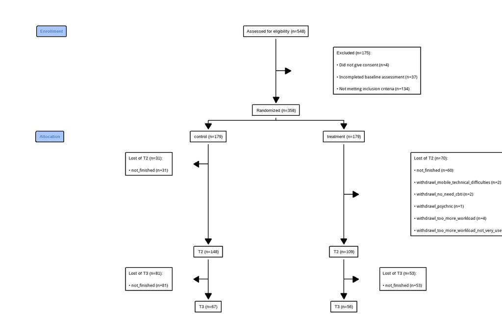

## Demographic information

| Characteristic | N | Overall, N = 358 | control, N = 179 | treatment, N = 179 | p-value |
| --- | --- | --- | --- | --- | --- |
| age | 358 | 36.34 ± 13.94 (18 - 73) | 35.95 ± 13.84 (18 - 73) | 36.72 ± 14.07 (18 - 71) | 0.599 |
| gender | 358 |  |  |  | 0.792 |
| female |  | 286 (80%) | 142 (79%) | 144 (80%) |  |
| male |  | 72 (20%) | 37 (21%) | 35 (20%) |  |
| occupation | 358 |  |  |  | 0.658 |
| civil |  | 13 (3.6%) | 4 (2.2%) | 9 (5.0%) |  |
| clerk |  | 57 (16%) | 30 (17%) | 27 (15%) |  |
| craft |  | 12 (3.4%) | 8 (4.5%) | 4 (2.2%) |  |
| homemaker |  | 26 (7.3%) | 14 (7.8%) | 12 (6.7%) |  |
| manager |  | 28 (7.8%) | 16 (8.9%) | 12 (6.7%) |  |
| other |  | 15 (4.2%) | 5 (2.8%) | 10 (5.6%) |  |
| professional |  | 39 (11%) | 16 (8.9%) | 23 (13%) |  |
| retired |  | 21 (5.9%) | 10 (5.6%) | 11 (6.1%) |  |
| service |  | 12 (3.4%) | 7 (3.9%) | 5 (2.8%) |  |
| student |  | 119 (33%) | 60 (34%) | 59 (33%) |  |
| unemploy |  | 16 (4.5%) | 9 (5.0%) | 7 (3.9%) |  |
| marital | 358 |  |  |  | 0.652 |
| divorced |  | 14 (3.9%) | 5 (2.8%) | 9 (5.0%) |  |
| married |  | 97 (27%) | 51 (28%) | 46 (26%) |  |
| other |  | 2 (0.6%) | 1 (0.6%) | 1 (0.6%) |  |
| separated |  | 5 (1.4%) | 1 (0.6%) | 4 (2.2%) |  |
| single |  | 235 (66%) | 119 (66%) | 116 (65%) |  |
| widowed |  | 5 (1.4%) | 2 (1.1%) | 3 (1.7%) |  |
| education | 358 |  |  |  | 0.914 |
| post-secondary |  | 52 (15%) | 28 (16%) | 24 (13%) |  |
| primary |  | 2 (0.6%) | 1 (0.6%) | 1 (0.6%) |  |
| secondary |  | 50 (14%) | 24 (13%) | 26 (15%) |  |
| university |  | 254 (71%) | 126 (70%) | 128 (72%) |  |
| family_income | 358 |  |  |  | 0.502 |
| 0_10000 |  | 56 (16%) | 27 (15%) | 29 (16%) |  |
| 10001_20000 |  | 75 (21%) | 38 (21%) | 37 (21%) |  |
| 20001_30000 |  | 73 (20%) | 42 (23%) | 31 (17%) |  |
| 30001_40000 |  | 60 (17%) | 31 (17%) | 29 (16%) |  |
| 40000_above |  | 94 (26%) | 41 (23%) | 53 (30%) |  |
| religion | 358 |  |  |  | 0.110 |
| buddhism |  | 16 (4.5%) | 7 (3.9%) | 9 (5.0%) |  |
| catholic |  | 17 (4.7%) | 11 (6.1%) | 6 (3.4%) |  |
| christianity |  | 73 (20%) | 30 (17%) | 43 (24%) |  |
| nil |  | 248 (69%) | 130 (73%) | 118 (66%) |  |
| other |  | 3 (0.8%) | 0 (0%) | 3 (1.7%) |  |
| taoism |  | 1 (0.3%) | 1 (0.6%) | 0 (0%) |  |
| source | 358 |  |  |  | 0.233 |
| bokss |  | 15 (4.2%) | 11 (6.1%) | 4 (2.2%) |  |
| facebook |  | 131 (37%) | 63 (35%) | 68 (38%) |  |
| instagram |  | 12 (3.4%) | 7 (3.9%) | 5 (2.8%) |  |
| other |  | 66 (18%) | 28 (16%) | 38 (21%) |  |
| refresh |  | 134 (37%) | 70 (39%) | 64 (36%) |  |

1Mean ± SD (Range); n (%)  
2Two Sample t-test; Pearson's Chi-squared test; Fisher's exact test

## Measurement

### Table

| Characteristic | N | Overall, N = 358 | control, N = 179 | treatment, N = 179 | p-value |
| --- | --- | --- | --- | --- | --- |
| isi | 358 | 13.47 ± 3.37 (8 - 21) | 13.53 ± 3.33 (8 - 21) | 13.40 ± 3.42 (8 - 21) | 0.719 |
| who | 358 | 9.90 ± 3.74 (0 - 21) | 9.82 ± 3.71 (1 - 20) | 9.98 ± 3.77 (0 - 21) | 0.682 |
| phq | 358 | 8.51 ± 5.01 (0 - 25) | 8.21 ± 4.98 (0 - 21) | 8.80 ± 5.03 (0 - 25) | 0.264 |
| gad | 358 | 7.78 ± 5.12 (0 - 21) | 7.54 ± 5.03 (0 - 21) | 8.02 ± 5.21 (0 - 21) | 0.376 |
| wsas | 358 | 16.73 ± 9.85 (0 - 40) | 16.77 ± 9.70 (0 - 39) | 16.69 ± 10.03 (0 - 40) | 0.936 |
| shps_arousal | 358 | 3.10 ± 0.69 (1 - 5) | 3.02 ± 0.68 (1 - 5) | 3.18 ± 0.69 (1 - 5) | 0.025 |
| shps_schedule | 358 | 3.55 ± 0.87 (1 - 6) | 3.53 ± 0.81 (2 - 6) | 3.58 ± 0.93 (1 - 6) | 0.653 |
| shps_behavior | 358 | 2.05 ± 0.66 (1 - 4) | 1.99 ± 0.61 (1 - 4) | 2.12 ± 0.71 (1 - 4) | 0.059 |
| shps_environment | 358 | 2.30 ± 0.82 (1 - 5) | 2.33 ± 0.84 (1 - 5) | 2.27 ± 0.80 (1 - 5) | 0.473 |
| dbas_consequence | 358 | 6.61 ± 1.75 (1 - 10) | 6.59 ± 1.82 (1 - 10) | 6.64 ± 1.68 (1 - 10) | 0.772 |
| dbas_worry | 358 | 14.37 ± 3.23 (3 - 20) | 14.20 ± 3.35 (3 - 20) | 14.54 ± 3.11 (3 - 20) | 0.319 |
| dbas_expectation | 358 | 7.03 ± 2.14 (1 - 10) | 7.17 ± 2.09 (1 - 10) | 6.89 ± 2.19 (1 - 10) | 0.209 |
| dbas_medication | 358 | 3.19 ± 2.07 (0 - 9) | 3.15 ± 2.04 (0 - 9) | 3.24 ± 2.09 (0 - 9) | 0.683 |
| psas_somatic | 358 | 1.88 ± 0.69 (1 - 5) | 1.86 ± 0.66 (1 - 4) | 1.91 ± 0.71 (1 - 5) | 0.539 |
| psas_cognitive | 358 | 2.92 ± 0.85 (1 - 5) | 2.87 ± 0.84 (1 - 5) | 2.97 ± 0.86 (1 - 5) | 0.270 |
| mic_attention | 358 | 1.36 ± 0.72 (0 - 3) | 1.30 ± 0.71 (0 - 3) | 1.42 ± 0.73 (0 - 3) | 0.110 |
| mic_executive | 358 | 1.31 ± 0.76 (0 - 3) | 1.28 ± 0.77 (0 - 3) | 1.35 ± 0.76 (0 - 3) | 0.406 |
| mic_memory | 358 | 1.37 ± 0.73 (0 - 3) | 1.33 ± 0.75 (0 - 3) | 1.40 ± 0.71 (0 - 3) | 0.397 |
| psqi_global | 358 | 10.87 ± 3.02 (2 - 19) | 10.72 ± 3.03 (4 - 17) | 11.01 ± 3.00 (2 - 19) | 0.363 |
| nb_pcs | 358 | 46.27 ± 8.63 (17 - 65) | 46.33 ± 8.91 (17 - 63) | 46.20 ± 8.38 (21 - 65) | 0.879 |
| nb_mcs | 358 | 39.94 ± 9.95 (8 - 65) | 39.90 ± 9.78 (8 - 62) | 39.98 ± 10.14 (8 - 65) | 0.935 |

1Mean ± SD (Range)  
2Two Sample t-test

### Plot

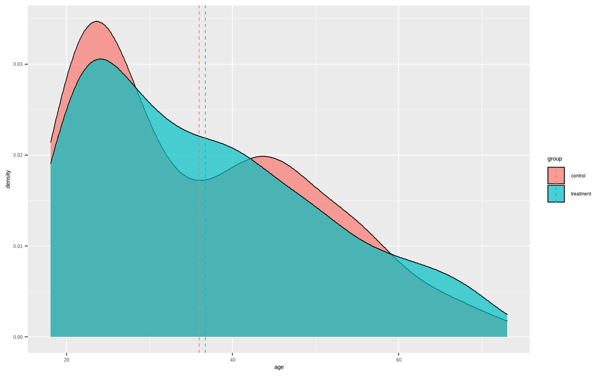

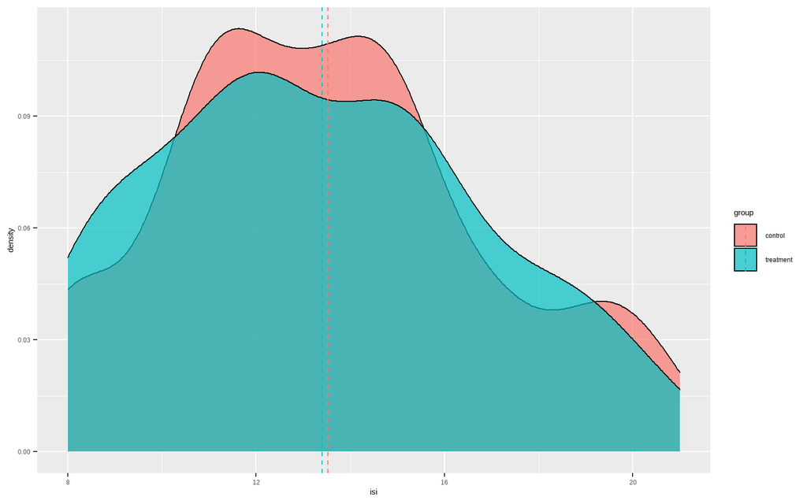

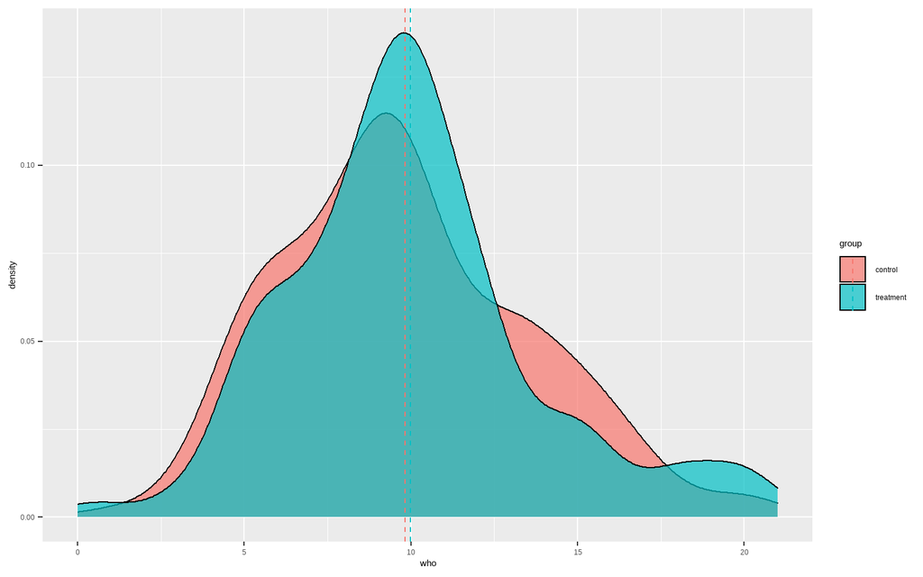

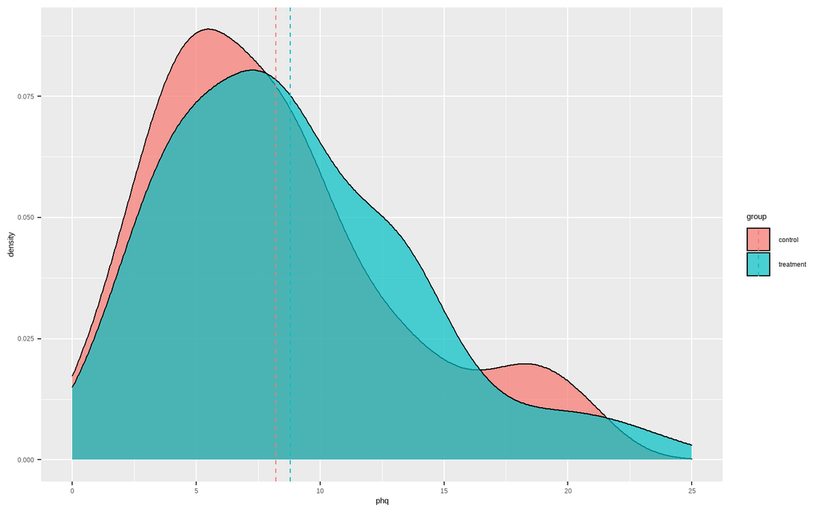

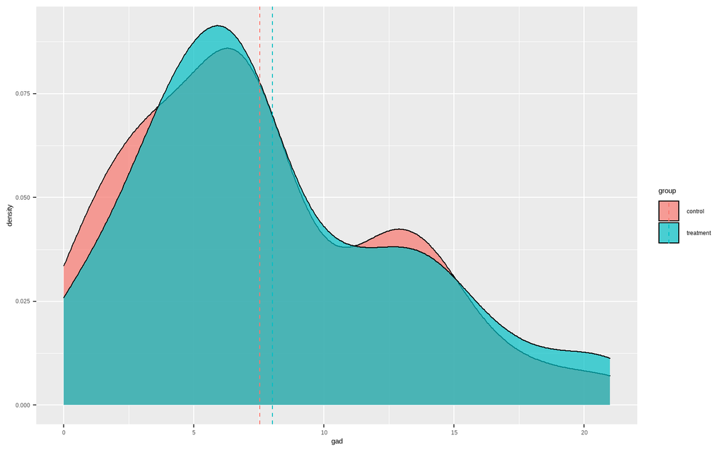

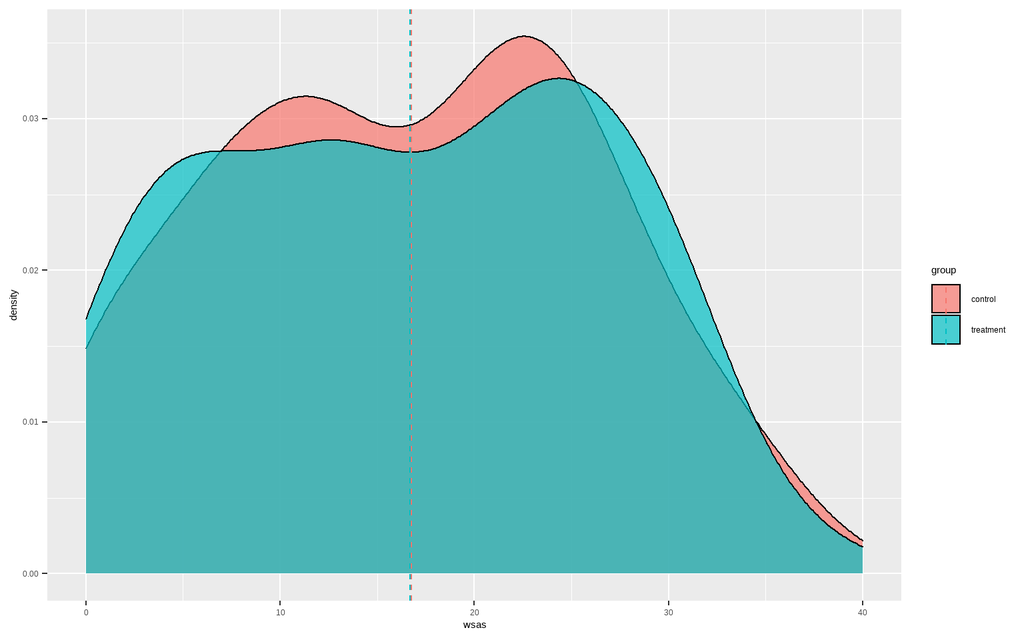

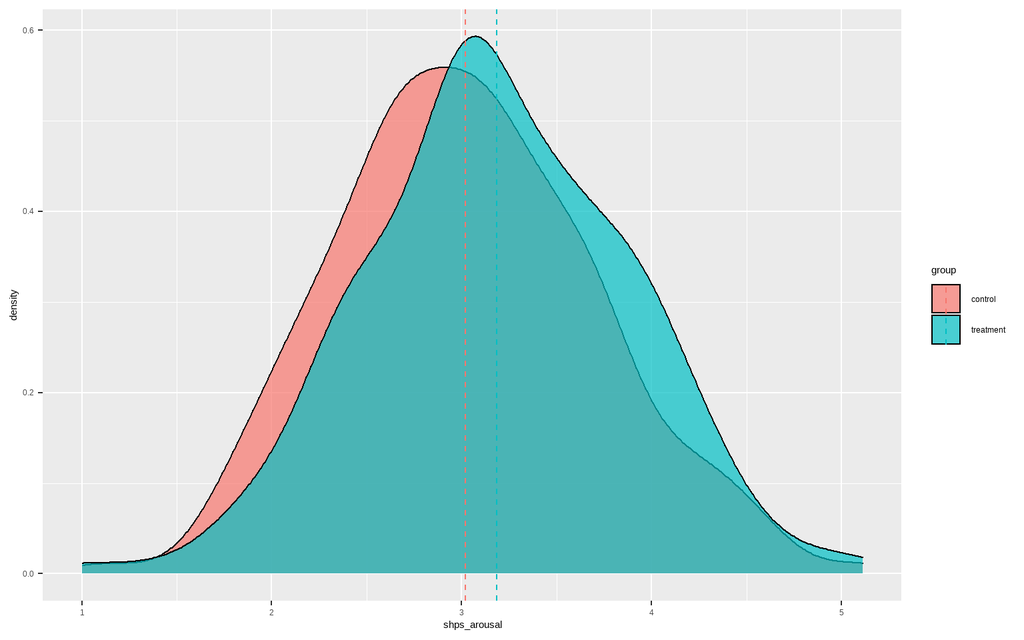

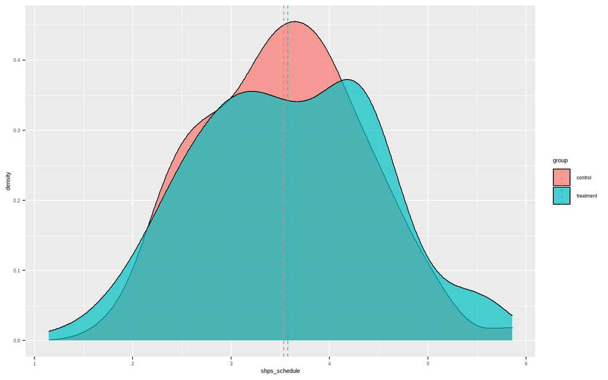

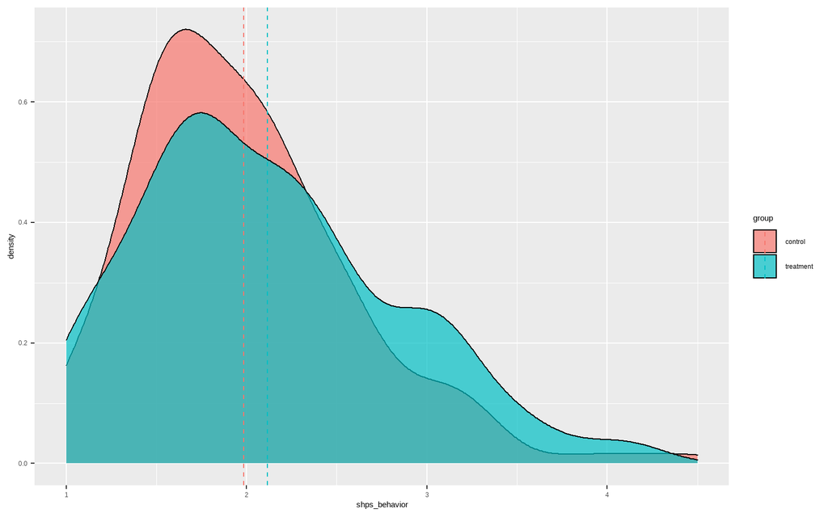

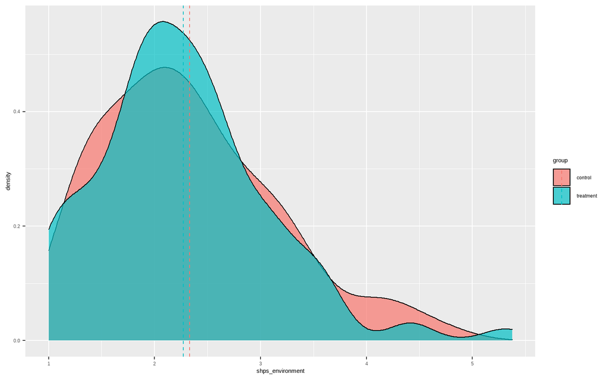

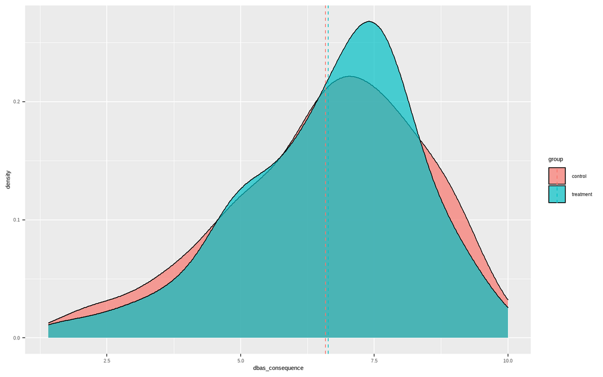

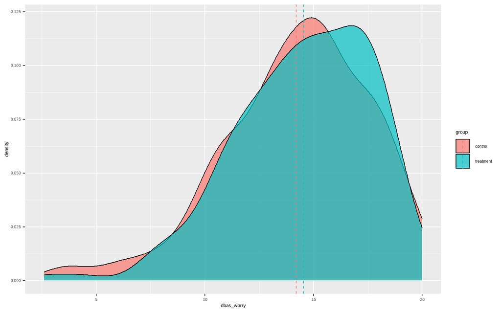

[10 more figures not shown]

## Data analysis

### Table

| Group | Characteristic | Beta | SE1 | 95% CI1 | p-value |
| --- | --- | --- | --- | --- | --- |
| isi | (Intercept) | 13.5 | 0.274 | 13.0, 14.1 |  |
|  | group |  |  |  |  |
|  | control | — | — | — |  |
|  | treatment | -0.128 | 0.388 | -0.889, 0.632 | 0.741 |
|  | time_point |  |  |  |  |
|  | 1st | — | — | — |  |
|  | 2nd | -2.45 | 0.328 | -3.10, -1.81 | 0.000 |
|  | group * time_point |  |  |  |  |
|  | treatment * 2nd | -2.99 | 0.494 | -3.96, -2.03 | 0.000 |
|  | Pseudo R square | 0.244 |  |  |  |
| who | (Intercept) | 9.82 | 0.294 | 9.24, 10.4 |  |
|  | group |  |  |  |  |
|  | control | — | — | — |  |
|  | treatment | 0.162 | 0.416 | -0.654, 0.98 | 0.697 |
|  | time_point |  |  |  |  |
|  | 1st | — | — | — |  |
|  | 2nd | 0.704 | 0.317 | 0.082, 1.33 | 0.027 |
|  | group * time_point |  |  |  |  |
|  | treatment * 2nd | 1.41 | 0.479 | 0.466, 2.34 | 0.004 |
|  | Pseudo R square | 0.041 |  |  |  |
| phq | (Intercept) | 8.21 | 0.374 | 7.48, 8.95 |  |
|  | group |  |  |  |  |
|  | control | — | — | — |  |
|  | treatment | 0.592 | 0.529 | -0.445, 1.63 | 0.264 |
|  | time_point |  |  |  |  |
|  | 1st | — | — | — |  |
|  | 2nd | -0.768 | 0.349 | -1.45, -0.084 | 0.029 |
|  | group * time_point |  |  |  |  |
|  | treatment * 2nd | -1.74 | 0.529 | -2.78, -0.706 | 0.001 |
|  | Pseudo R square | 0.030 |  |  |  |

[output cut: 180 more lines]

1SE = Standard Error, CI = Confidence Interval

### Text

**isi**

We fitted a linear mixed model (estimated using REML and nloptwrap optimizer) to predict isi with group and time_point (formula: isi ~ 1 + group + time_point + group * time_point). The model included login_id as random effect (formula: ~1 | login_id). The model’s total explanatory power is substantial (conditional R2 = 0.53) and the part related to the fixed effects alone (marginal R2) is of 0.24. The model’s intercept, corresponding to group = control and time_point = 1st , is at 13.53 (S.E. = 0.27, p < .001, 95% CI [12.99, 14.07]). Within this model:

- The effect of group [treatment] is statistically non-significant and negative (beta = -0.13, S.E. = 0.39, p = 0.741, 95% CI [-0.89, 0.63]; Std. beta = -0.03, 95% CI [-0.21, 0.15])
- The effect of time point [2nd] is statistically significant and negative (beta = -2.45, S.E. = 0.33, p < .001, 95% CI [-3.10, -1.81]; Std. beta = -0.58, 95% CI [-0.73, -0.43])
- The interaction effect of time point [2nd] on group [treatment] is statistically significant and negative (beta = -2.99, S.E. = 0.49, p < .001, 95% CI [-3.96, -2.03]; Std. beta = -0.71, 95% CI [-0.93, -0.48])

Standardized parameters were obtained by fitting the model on a standardized version of the dataset. 95% Confidence Intervals (CIs) and p-values were computed using a Wald normal distribution approximation.

**who**

We fitted a linear mixed model (estimated using REML and nloptwrap optimizer) to predict who with group and time_point (formula: who ~ 1 + group + time_point + group * time_point). The model included login_id as random effect (formula: ~1 | login_id). The model’s total explanatory power is substantial (conditional R2 = 0.52) and the part related to the fixed effects alone (marginal R2) is of 0.04. The model’s intercept, corresponding to group = control and time_point = 1st , is at 9.82 (S.E. = 0.29, p < .001, 95% CI [9.24, 10.40]). Within this model:

- The effect of group [treatment] is statistically non-significant and positive (beta = 0.16, S.E. = 0.42, p = 0.697, 95% CI [-0.65, 0.98]; Std. beta = 0.04, 95% CI [-0.16, 0.24])
- The effect of time point [2nd] is statistically significant and positive (beta = 0.70, S.E. = 0.32, p = 0.027, 95% CI [0.08, 1.33]; Std. beta = 0.17, 95% CI [0.02, 0.33])
- The interaction effect of time point [2nd] on group [treatment] is statistically significant and positive (beta = 1.41, S.E. = 0.48, p = 0.003, 95% CI [0.47, 2.34]; Std. beta = 0.35, 95% CI [0.12, 0.58])

Standardized parameters were obtained by fitting the model on a standardized version of the dataset. 95% Confidence Intervals (CIs) and p-values were computed using a Wald normal distribution approximation.

**phq**

We fitted a linear mixed model (estimated using REML and nloptwrap optimizer) to predict phq with group and time_point (formula: phq ~ 1 + group + time_point + group * time_point). The model included login_id as random effect (formula: ~1 | login_id). The model’s total explanatory power is substantial (conditional R2 = 0.64) and the part related to the fixed effects alone (marginal R2) is of 0.03. The model’s intercept, corresponding to group = control and time_point = 1st , is at 8.21 (S.E. = 0.37, p < .001, 95% CI [7.48, 8.95]). Within this model:

- The effect of group [treatment] is statistically non-significant and positive (beta = 0.59, S.E. = 0.53, p = 0.263, 95% CI [-0.45, 1.63]; Std. beta = 0.12, 95% CI [-0.09, 0.32])
- The effect of time point [2nd] is statistically significant and negative (beta = -0.77, S.E. = 0.35, p = 0.028, 95% CI [-1.45, -0.08]; Std. beta = -0.15, 95% CI [-0.29, -0.02])
- The interaction effect of time point [2nd] on group [treatment] is statistically significant and negative (beta = -1.74, S.E. = 0.53, p < .001, 95% CI [-2.78, -0.71]; Std. beta = -0.34, 95% CI [-0.55, -0.14])

Standardized parameters were obtained by fitting the model on a standardized version of the dataset. 95% Confidence Intervals (CIs) and p-values were computed using a Wald normal distribution approximation.

**gad**

We fitted a linear mixed model (estimated using REML and nloptwrap optimizer) to predict gad with group and time_point (formula: gad ~ 1 + group + time_point + group * time_point). The model included login_id as random effect (formula: ~1 | login_id). The model’s total explanatory power is substantial (conditional R2 = 0.65) and the part related to the fixed effects alone (marginal R2) is of 0.03. The model’s intercept, corresponding to group = control and time_point = 1st , is at 7.54 (S.E. = 0.38, p < .001, 95% CI [6.79, 8.29]). Within this model:

- The effect of group [treatment] is statistically non-significant and positive (beta = 0.48, S.E. = 0.54, p = 0.375, 95% CI [-0.58, 1.54]; Std. beta = 0.09, 95% CI [-0.11, 0.30])
- The effect of time point [2nd] is statistically non-significant and negative (beta = -0.44, S.E. = 0.35, p = 0.208, 95% CI [-1.12, 0.24]; Std. beta = -0.08, 95% CI [-0.22, 0.05])
- The interaction effect of time point [2nd] on group [treatment] is statistically significant and negative (beta = -2.07, S.E. = 0.53, p < .001, 95% CI [-3.11, -1.03]; Std. beta = -0.40, 95% CI [-0.60, -0.20])

Standardized parameters were obtained by fitting the model on a standardized version of the dataset. 95% Confidence Intervals (CIs) and p-values were computed using a Wald normal distribution approximation.

**wsas**

We fitted a linear mixed model (estimated using REML and nloptwrap optimizer) to predict wsas with group and time_point (formula: wsas ~ 1 + group + time_point + group * time_point). The model included login_id as random effect (formula: ~1 | login_id). The model’s total explanatory power is substantial (conditional R2 = 0.61) and the part related to the fixed effects alone (marginal R2) is of 0.02. The model’s intercept, corresponding to group = control and time_point = 1st , is at 16.77 (S.E. = 0.74, p < .001, 95% CI [15.32, 18.23]). Within this model:

- The effect of group [treatment] is statistically non-significant and negative (beta = -0.08, S.E. = 1.05, p = 0.936, 95% CI [-2.14, 1.97]; Std. beta = -8.37e-03, 95% CI [-0.21, 0.20])
- The effect of time point [2nd] is statistically non-significant and negative (beta = -0.82, S.E. = 0.71, p = 0.247, 95% CI [-2.22, 0.57]; Std. beta = -0.08, 95% CI [-0.22, 0.06])
- The interaction effect of time point [2nd] on group [treatment] is statistically significant and negative (beta = -2.94, S.E. = 1.08, p = 0.006, 95% CI [-5.06, -0.83]; Std. beta = -0.29, 95% CI [-0.51, -0.08])

Standardized parameters were obtained by fitting the model on a standardized version of the dataset. 95% Confidence Intervals (CIs) and p-values were computed using a Wald normal distribution approximation.

**shps_arousal**

We fitted a linear mixed model (estimated using REML and nloptwrap optimizer) to predict shps_arousal with group and time_point (formula: shps_arousal ~ 1 + group + time_point + group * time_point). The model included login_id as random effect (formula: ~1 | login_id). The model’s total explanatory power is substantial (conditional R2 = 0.49) and the part related to the fixed effects alone (marginal R2) is of 0.10. The model’s intercept, corresponding to group = control and time_point = 1st , is at 3.02 (S.E. = 0.05, p < .001, 95% CI [2.92, 3.13]). Within this model:

- The effect of group [treatment] is statistically significant and positive (beta = 0.16, S.E. = 0.08, p = 0.034, 95% CI [0.01, 0.31]; Std. beta = 0.21, 95% CI [0.02, 0.41])
- The effect of time point [2nd] is statistically significant and negative (beta = -0.20, S.E. = 0.06, p = 0.002, 95% CI [-0.32, -0.07]; Std. beta = -0.26, 95% CI [-0.42, -0.10])
- The interaction effect of time point [2nd] on group [treatment] is statistically significant and negative (beta = -0.48, S.E. = 0.09, p < .001, 95% CI [-0.66, -0.30]; Std. beta = -0.63, 95% CI [-0.87, -0.39])

Standardized parameters were obtained by fitting the model on a standardized version of the dataset. 95% Confidence Intervals (CIs) and p-values were computed using a Wald normal distribution approximation.

**shps_schedule**

We fitted a linear mixed model (estimated using REML and nloptwrap optimizer) to predict shps_schedule with group and time_point (formula: shps_schedule ~ 1 + group + time_point + group * time_point). The model included login_id as random effect (formula: ~1 | login_id). The model’s total explanatory power is substantial (conditional R2 = 0.64) and the part related to the fixed effects alone (marginal R2) is of 0.03. The model’s intercept, corresponding to group = control and time_point = 1st , is at 3.53 (S.E. = 0.07, p < .001, 95% CI [3.40, 3.66]). Within this model:

- The effect of group [treatment] is statistically non-significant and positive (beta = 0.04, S.E. = 0.09, p = 0.659, 95% CI [-0.14, 0.23]; Std. beta = 0.05, 95% CI [-0.16, 0.25])
- The effect of time point [2nd] is statistically non-significant and negative (beta = -0.10, S.E. = 0.06, p = 0.106, 95% CI [-0.22, 0.02]; Std. beta = -0.11, 95% CI [-0.25, 0.02])
- The interaction effect of time point [2nd] on group [treatment] is statistically significant and negative (beta = -0.35, S.E. = 0.09, p < .001, 95% CI [-0.53, -0.16]; Std. beta = -0.38, 95% CI [-0.59, -0.18])

Standardized parameters were obtained by fitting the model on a standardized version of the dataset. 95% Confidence Intervals (CIs) and p-values were computed using a Wald normal distribution approximation.

**shps_behavior**

We fitted a linear mixed model (estimated using REML and nloptwrap optimizer) to predict shps_behavior with group and time_point (formula: shps_behavior ~ 1 + group + time_point + group * time_point). The model included login_id as random effect (formula: ~1 | login_id). The model’s total explanatory power is substantial (conditional R2 = 0.56) and the part related to the fixed effects alone (marginal R2) is of 0.01. The model’s intercept, corresponding to group = control and time_point = 1st , is at 1.99 (S.E. = 0.05, p < .001, 95% CI [1.88, 2.09]). Within this model:

- The effect of group [treatment] is statistically non-significant and positive (beta = 0.13, S.E. = 0.07, p = 0.069, 95% CI [-0.01, 0.27]; Std. beta = 0.19, 95% CI [-0.01, 0.40])
- The effect of time point [2nd] is statistically non-significant and positive (beta = 0.02, S.E. = 0.05, p = 0.641, 95% CI [-0.08, 0.13]; Std. beta = 0.04, 95% CI [-0.11, 0.18])
- The interaction effect of time point [2nd] on group [treatment] is statistically significant and negative (beta = -0.24, S.E. = 0.08, p = 0.002, 95% CI [-0.40, -0.09]; Std. beta = -0.35, 95% CI [-0.58, -0.13])

Standardized parameters were obtained by fitting the model on a standardized version of the dataset. 95% Confidence Intervals (CIs) and p-values were computed using a Wald normal distribution approximation.

**shps_environment**

We fitted a linear mixed model (estimated using REML and nloptwrap optimizer) to predict shps_environment with group and time_point (formula: shps_environment ~ 1 + group + time_point + group * time_point). The model included login_id as random effect (formula: ~1 | login_id). The model’s total explanatory power is substantial (conditional R2 = 0.54) and the part related to the fixed effects alone (marginal R2) is of 6.98e-03. The model’s intercept, corresponding to group = control and time_point = 1st , is at 2.33 (S.E. = 0.06, p < .001, 95% CI [2.21, 2.45]). Within this model:

- The effect of group [treatment] is statistically non-significant and negative (beta = -0.06, S.E. = 0.09, p = 0.481, 95% CI [-0.24, 0.11]; Std. beta = -0.07, 95% CI [-0.28, 0.13])
- The effect of time point [2nd] is statistically non-significant and negative (beta = -0.06, S.E. = 0.06, p = 0.344, 95% CI [-0.19, 0.07]; Std. beta = -0.07, 95% CI [-0.22, 0.08])
- The interaction effect of time point [2nd] on group [treatment] is statistically non-significant and negative (beta = -0.09, S.E. = 0.10, p = 0.379, 95% CI [-0.28, 0.11]; Std. beta = -0.10, 95% CI [-0.33, 0.13])

Standardized parameters were obtained by fitting the model on a standardized version of the dataset. 95% Confidence Intervals (CIs) and p-values were computed using a Wald normal distribution approximation.

**dbas_consequence**

We fitted a linear mixed model (estimated using REML and nloptwrap optimizer) to predict dbas_consequence with group and time_point (formula: dbas_consequence ~ 1 + group + time_point + group * time_point). The model included login_id as random effect (formula: ~1 | login_id). The model’s total explanatory power is substantial (conditional R2 = 0.56) and the part related to the fixed effects alone (marginal R2) is of 0.08. The model’s intercept, corresponding to group = control and time_point = 1st , is at 6.59 (S.E. = 0.13, p < .001, 95% CI [6.33, 6.85]). Within this model:

- The effect of group [treatment] is statistically non-significant and positive (beta = 0.05, S.E. = 0.19, p = 0.777, 95% CI [-0.32, 0.43]; Std. beta = 0.03, 95% CI [-0.17, 0.23])
- The effect of time point [2nd] is statistically significant and negative (beta = -0.34, S.E. = 0.14, p = 0.017, 95% CI [-0.61, -0.06]; Std. beta = -0.18, 95% CI [-0.33, -0.03])
- The interaction effect of time point [2nd] on group [treatment] is statistically significant and negative (beta = -1.11, S.E. = 0.21, p < .001, 95% CI [-1.53, -0.69]; Std. beta = -0.59, 95% CI [-0.82, -0.37])

Standardized parameters were obtained by fitting the model on a standardized version of the dataset. 95% Confidence Intervals (CIs) and p-values were computed using a Wald normal distribution approximation.

**dbas_worry**

We fitted a linear mixed model (estimated using REML and nloptwrap optimizer) to predict dbas_worry with group and time_point (formula: dbas_worry ~ 1 + group + time_point + group * time_point). The model included login_id as random effect (formula: ~1 | login_id). The model’s total explanatory power is substantial (conditional R2 = 0.51) and the part related to the fixed effects alone (marginal R2) is of 0.13. The model’s intercept, corresponding to group = control and time_point = 1st , is at 14.20 (S.E. = 0.27, p < .001, 95% CI [13.67, 14.73]). Within this model:

- The effect of group [treatment] is statistically non-significant and positive (beta = 0.34, S.E. = 0.38, p = 0.370, 95% CI [-0.40, 1.09]; Std. beta = 0.09, 95% CI [-0.10, 0.28])
- The effect of time point [2nd] is statistically significant and negative (beta = -1.23, S.E. = 0.31, p < .001, 95% CI [-1.83, -0.63]; Std. beta = -0.32, 95% CI [-0.47, -0.16])
- The interaction effect of time point [2nd] on group [treatment] is statistically significant and negative (beta = -2.71, S.E. = 0.46, p < .001, 95% CI [-3.62, -1.81]; Std. beta = -0.70, 95% CI [-0.94, -0.47])

Standardized parameters were obtained by fitting the model on a standardized version of the dataset. 95% Confidence Intervals (CIs) and p-values were computed using a Wald normal distribution approximation.

**dbas_expectation**

We fitted a linear mixed model (estimated using REML and nloptwrap optimizer) to predict dbas_expectation with group and time_point (formula: dbas_expectation ~ 1 + group + time_point + group * time_point). The model included login_id as random effect (formula: ~1 | login_id). The model’s total explanatory power is substantial (conditional R2 = 0.50) and the part related to the fixed effects alone (marginal R2) is of 0.08. The model’s intercept, corresponding to group = control and time_point = 1st , is at 7.17 (S.E. = 0.17, p < .001, 95% CI [6.84, 7.50]). Within this model:

- The effect of group [treatment] is statistically non-significant and negative (beta = -0.28, S.E. = 0.24, p = 0.231, 95% CI [-0.75, 0.18]; Std. beta = -0.12, 95% CI [-0.32, 0.08])
- The effect of time point [2nd] is statistically non-significant and negative (beta = -0.35, S.E. = 0.19, p = 0.062, 95% CI [-0.72, 0.02]; Std. beta = -0.15, 95% CI [-0.31, 7.58e-03])
- The interaction effect of time point [2nd] on group [treatment] is statistically significant and negative (beta = -1.24, S.E. = 0.28, p < .001, 95% CI [-1.79, -0.68]; Std. beta = -0.53, 95% CI [-0.77, -0.29])

Standardized parameters were obtained by fitting the model on a standardized version of the dataset. 95% Confidence Intervals (CIs) and p-values were computed using a Wald normal distribution approximation.

**dbas_medication**

We fitted a linear mixed model (estimated using REML and nloptwrap optimizer) to predict dbas_medication with group and time_point (formula: dbas_medication ~ 1 + group + time_point + group * time_point). The model included login_id as random effect (formula: ~1 | login_id). The model’s total explanatory power is substantial (conditional R2 = 0.50) and the part related to the fixed effects alone (marginal R2) is of 8.04e-03. The model’s intercept, corresponding to group = control and time_point = 1st , is at 3.15 (S.E. = 0.16, p < .001, 95% CI [2.83, 3.46]). Within this model:

- The effect of group [treatment] is statistically non-significant and positive (beta = 0.09, S.E. = 0.23, p = 0.692, 95% CI [-0.35, 0.53]; Std. beta = 0.04, 95% CI [-0.17, 0.25])
- The effect of time point [2nd] is statistically significant and positive (beta = 0.36, S.E. = 0.17, p = 0.035, 95% CI [0.03, 0.70]; Std. beta = 0.17, 95% CI [0.01, 0.33])
- The interaction effect of time point [2nd] on group [treatment] is statistically significant and negative (beta = -0.67, S.E. = 0.26, p = 0.010, 95% CI [-1.18, -0.16]; Std. beta = -0.31, 95% CI [-0.55, -0.08])

Standardized parameters were obtained by fitting the model on a standardized version of the dataset. 95% Confidence Intervals (CIs) and p-values were computed using a Wald normal distribution approximation.

**psas_somatic**

We fitted a linear mixed model (estimated using REML and nloptwrap optimizer) to predict psas_somatic with group and time_point (formula: psas_somatic ~ 1 + group + time_point + group * time_point). The model included login_id as random effect (formula: ~1 | login_id). The model’s total explanatory power is substantial (conditional R2 = 0.62) and the part related to the fixed effects alone (marginal R2) is of 0.02. The model’s intercept, corresponding to group = control and time_point = 1st , is at 1.86 (S.E. = 0.05, p < .001, 95% CI [1.76, 1.96]). Within this model:

- The effect of group [treatment] is statistically non-significant and positive (beta = 0.04, S.E. = 0.07, p = 0.538, 95% CI [-0.10, 0.19]; Std. beta = 0.06, 95% CI [-0.14, 0.27])
- The effect of time point [2nd] is statistically significant and positive (beta = 0.14, S.E. = 0.05, p = 0.003, 95% CI [0.05, 0.24]; Std. beta = 0.21, 95% CI [0.07, 0.35])
- The interaction effect of time point [2nd] on group [treatment] is statistically significant and negative (beta = -0.31, S.E. = 0.07, p < .001, 95% CI [-0.45, -0.16]; Std. beta = -0.44, 95% CI [-0.65, -0.23])

Standardized parameters were obtained by fitting the model on a standardized version of the dataset. 95% Confidence Intervals (CIs) and p-values were computed using a Wald normal distribution approximation.

**psas_cognitive**

We fitted a linear mixed model (estimated using REML and nloptwrap optimizer) to predict psas_cognitive with group and time_point (formula: psas_cognitive ~ 1 + group + time_point + group * time_point). The model included login_id as random effect (formula: ~1 | login_id). The model’s total explanatory power is substantial (conditional R2 = 0.64) and the part related to the fixed effects alone (marginal R2) is of 0.07. The model’s intercept, corresponding to group = control and time_point = 1st , is at 2.87 (S.E. = 0.06, p < .001, 95% CI [2.75, 3.00]). Within this model:

- The effect of group [treatment] is statistically non-significant and positive (beta = 0.10, S.E. = 0.09, p = 0.267, 95% CI [-0.08, 0.27]; Std. beta = 0.11, 95% CI [-0.09, 0.31])
- The effect of time point [2nd] is statistically significant and negative (beta = -0.20, S.E. = 0.06, p < .001, 95% CI [-0.32, -0.09]; Std. beta = -0.23, 95% CI [-0.37, -0.10])
- The interaction effect of time point [2nd] on group [treatment] is statistically significant and negative (beta = -0.44, S.E. = 0.09, p < .001, 95% CI [-0.61, -0.26]; Std. beta = -0.50, 95% CI [-0.70, -0.29])

Standardized parameters were obtained by fitting the model on a standardized version of the dataset. 95% Confidence Intervals (CIs) and p-values were computed using a Wald normal distribution approximation.

**mic_attention**

We fitted a linear mixed model (estimated using REML and nloptwrap optimizer) to predict mic_attention with group and time_point (formula: mic_attention ~ 1 + group + time_point + group * time_point). The model included login_id as random effect (formula: ~1 | login_id). The model’s total explanatory power is substantial (conditional R2 = 0.60) and the part related to the fixed effects alone (marginal R2) is of 0.01. The model’s intercept, corresponding to group = control and time_point = 1st , is at 1.30 (S.E. = 0.06, p < .001, 95% CI [1.19, 1.41]). Within this model:

- The effect of group [treatment] is statistically non-significant and positive (beta = 0.12, S.E. = 0.08, p = 0.126, 95% CI [-0.03, 0.28]; Std. beta = 0.16, 95% CI [-0.04, 0.37])
- The effect of time point [2nd] is statistically non-significant and negative (beta = -0.02, S.E. = 0.05, p = 0.689, 95% CI [-0.13, 0.09]; Std. beta = -0.03, 95% CI [-0.17, 0.11])
- The interaction effect of time point [2nd] on group [treatment] is statistically significant and negative (beta = -0.25, S.E. = 0.08, p = 0.003, 95% CI [-0.41, -0.08]; Std. beta = -0.33, 95% CI [-0.54, -0.11])

Standardized parameters were obtained by fitting the model on a standardized version of the dataset. 95% Confidence Intervals (CIs) and p-values were computed using a Wald normal distribution approximation.

**mic_executive**

We fitted a linear mixed model (estimated using REML and nloptwrap optimizer) to predict mic_executive with group and time_point (formula: mic_executive ~ 1 + group + time_point + group * time_point). The model included login_id as random effect (formula: ~1 | login_id). The model’s total explanatory power is substantial (conditional R2 = 0.63) and the part related to the fixed effects alone (marginal R2) is of 7.16e-03. The model’s intercept, corresponding to group = control and time_point = 1st , is at 1.28 (S.E. = 0.06, p < .001, 95% CI [1.17, 1.39]). Within this model:

- The effect of group [treatment] is statistically non-significant and positive (beta = 0.07, S.E. = 0.08, p = 0.411, 95% CI [-0.09, 0.23]; Std. beta = 0.09, 95% CI [-0.12, 0.29])
- The effect of time point [2nd] is statistically non-significant and negative (beta = -0.03, S.E. = 0.05, p = 0.534, 95% CI [-0.14, 0.07]; Std. beta = -0.04, 95% CI [-0.18, 0.09])
- The interaction effect of time point [2nd] on group [treatment] is statistically non-significant and negative (beta = -0.16, S.E. = 0.08, p = 0.052, 95% CI [-0.32, 1.28e-03]; Std. beta = -0.21, 95% CI [-0.41, 1.65e-03])

Standardized parameters were obtained by fitting the model on a standardized version of the dataset. 95% Confidence Intervals (CIs) and p-values were computed using a Wald normal distribution approximation.

**mic_memory**

We fitted a linear mixed model (estimated using REML and nloptwrap optimizer) to predict mic_memory with group and time_point (formula: mic_memory ~ 1 + group + time_point + group * time_point). The model included login_id as random effect (formula: ~1 | login_id). The model’s total explanatory power is substantial (conditional R2 = 0.63) and the part related to the fixed effects alone (marginal R2) is of 0.01. The model’s intercept, corresponding to group = control and time_point = 1st , is at 1.33 (S.E. = 0.06, p < .001, 95% CI [1.22, 1.44]). Within this model:

- The effect of group [treatment] is statistically non-significant and positive (beta = 0.07, S.E. = 0.08, p = 0.412, 95% CI [-0.09, 0.22]; Std. beta = 0.09, 95% CI [-0.12, 0.29])
- The effect of time point [2nd] is statistically non-significant and positive (beta = 0.03, S.E. = 0.05, p = 0.561, 95% CI [-0.07, 0.13]; Std. beta = 0.04, 95% CI [-0.10, 0.18])
- The interaction effect of time point [2nd] on group [treatment] is statistically significant and negative (beta = -0.28, S.E. = 0.08, p < .001, 95% CI [-0.43, -0.12]; Std. beta = -0.36, 95% CI [-0.57, -0.16])

Standardized parameters were obtained by fitting the model on a standardized version of the dataset. 95% Confidence Intervals (CIs) and p-values were computed using a Wald normal distribution approximation.

**psqi_global**

We fitted a linear mixed model (estimated using REML and nloptwrap optimizer) to predict psqi_global with group and time_point (formula: psqi_global ~ 1 + group + time_point + group * time_point). The model included login_id as random effect (formula: ~1 | login_id). The model’s total explanatory power is substantial (conditional R2 = 0.52) and the part related to the fixed effects alone (marginal R2) is of 0.13. The model’s intercept, corresponding to group = control and time_point = 1st , is at 10.72 (S.E. = 0.23, p < .001, 95% CI [10.27, 11.17]). Within this model:

- The effect of group [treatment] is statistically non-significant and positive (beta = 0.29, S.E. = 0.33, p = 0.374, 95% CI [-0.35, 0.93]; Std. beta = 0.09, 95% CI [-0.11, 0.28])
- The effect of time point [2nd] is statistically significant and negative (beta = -1.31, S.E. = 0.26, p < .001, 95% CI [-1.82, -0.80]; Std. beta = -0.40, 95% CI [-0.55, -0.24])
- The interaction effect of time point [2nd] on group [treatment] is statistically significant and negative (beta = -1.87, S.E. = 0.39, p < .001, 95% CI [-2.64, -1.10]; Std. beta = -0.56, 95% CI [-0.80, -0.33])

Standardized parameters were obtained by fitting the model on a standardized version of the dataset. 95% Confidence Intervals (CIs) and p-values were computed using a Wald normal distribution approximation.

**nb_pcs**

We fitted a linear mixed model (estimated using REML and nloptwrap optimizer) to predict nb_pcs with group and time_point (formula: nb_pcs ~ 1 + group + time_point + group * time_point). The model included login_id as random effect (formula: ~1 | login_id). The model’s total explanatory power is substantial (conditional R2 = 0.63) and the part related to the fixed effects alone (marginal R2) is of 9.38e-03. The model’s intercept, corresponding to group = control and time_point = 1st , is at 46.33 (S.E. = 0.66, p < .001, 95% CI [45.04, 47.63]). Within this model:

- The effect of group [treatment] is statistically non-significant and negative (beta = -0.14, S.E. = 0.93, p = 0.882, 95% CI [-1.96, 1.69]; Std. beta = -0.02, 95% CI [-0.22, 0.19])
- The effect of time point [2nd] is statistically non-significant and negative (beta = -0.87, S.E. = 0.62, p = 0.158, 95% CI [-2.09, 0.34]; Std. beta = -0.10, 95% CI [-0.24, 0.04])
- The interaction effect of time point [2nd] on group [treatment] is statistically significant and positive (beta = 2.77, S.E. = 0.94, p = 0.003, 95% CI [0.93, 4.61]; Std. beta = 0.31, 95% CI [0.11, 0.52])

Standardized parameters were obtained by fitting the model on a standardized version of the dataset. 95% Confidence Intervals (CIs) and p-values were computed using a Wald normal distribution approximation.

**nb_mcs**

We fitted a linear mixed model (estimated using REML and nloptwrap optimizer) to predict nb_mcs with group and time_point (formula: nb_mcs ~ 1 + group + time_point + group * time_point). The model included login_id as random effect (formula: ~1 | login_id). The model’s total explanatory power is substantial (conditional R2 = 0.60) and the part related to the fixed effects alone (marginal R2) is of 0.04. The model’s intercept, corresponding to group = control and time_point = 1st , is at 39.90 (S.E. = 0.76, p < .001, 95% CI [38.41, 41.39]). Within this model:

- The effect of group [treatment] is statistically non-significant and positive (beta = 0.09, S.E. = 1.07, p = 0.937, 95% CI [-2.02, 2.19]; Std. beta = 8.19e-03, 95% CI [-0.19, 0.21])
- The effect of time point [2nd] is statistically significant and positive (beta = 2.00, S.E. = 0.75, p = 0.007, 95% CI [0.54, 3.47]; Std. beta = 0.19, 95% CI [0.05, 0.33])
- The interaction effect of time point [2nd] on group [treatment] is statistically significant and positive (beta = 3.57, S.E. = 1.13, p = 0.002, 95% CI [1.35, 5.78]; Std. beta = 0.34, 95% CI [0.13, 0.56])

Standardized parameters were obtained by fitting the model on a standardized version of the dataset. 95% Confidence Intervals (CIs) and p-values were computed using a Wald normal distribution approximation.

## Likelihood ratio tests

| outcome | model | npar | AIC | BIC | logLik | deviance | Chisq | Df | p |
| --- | --- | --- | --- | --- | --- | --- | --- | --- | --- |
| isi | null | 3 | 3,522.910 | 3,536.175 | -1,758.455 | 3,516.910 |  |  |  |
| isi | random | 6 | 3,314.445 | 3,340.975 | -1,651.223 | 3,302.445 | 214.465 | 3 | 0.000 |
| who | null | 3 | 3,399.902 | 3,413.167 | -1,696.951 | 3,393.902 |  |  |  |
| who | random | 6 | 3,366.647 | 3,393.177 | -1,677.323 | 3,354.647 | 39.255 | 3 | 0.000 |
| phq | null | 3 | 3,641.269 | 3,654.534 | -1,817.635 | 3,635.269 |  |  |  |
| phq | random | 6 | 3,605.473 | 3,632.003 | -1,796.737 | 3,593.473 | 41.796 | 3 | 0.000 |
| gad | null | 3 | 3,656.135 | 3,669.399 | -1,825.067 | 3,650.135 |  |  |  |
| gad | random | 6 | 3,623.473 | 3,650.003 | -1,805.736 | 3,611.473 | 38.662 | 3 | 0.000 |
| wsas | null | 3 | 4,476.214 | 4,489.478 | -2,235.107 | 4,470.214 |  |  |  |
| wsas | random | 6 | 4,458.977 | 4,485.507 | -2,223.489 | 4,446.977 | 23.236 | 3 | 0.000 |
| shps_arousal | null | 3 | 1,391.570 | 1,404.835 | -692.785 | 1,385.570 |  |  |  |
| shps_arousal | random | 6 | 1,306.139 | 1,332.669 | -647.069 | 1,294.139 | 91.431 | 3 | 0.000 |
| shps_schedule | null | 3 | 1,515.524 | 1,528.788 | -754.762 | 1,509.524 |  |  |  |
| shps_schedule | random | 6 | 1,480.957 | 1,507.486 | -734.478 | 1,468.957 | 40.567 | 3 | 0.000 |
| shps_behavior | null | 3 | 1,204.251 | 1,217.515 | -599.125 | 1,198.251 |  |  |  |
| shps_behavior | random | 6 | 1,195.805 | 1,222.335 | -591.902 | 1,183.805 | 14.446 | 3 | 0.002 |
| shps_environment | null | 3 | 1,442.987 | 1,456.252 | -718.493 | 1,436.987 |  |  |  |
| shps_environment | random | 6 | 1,442.926 | 1,469.456 | -715.463 | 1,430.926 | 6.061 | 3 | 0.109 |
| dbas_consequence | null | 3 | 2,464.642 | 2,477.907 | -1,229.321 | 2,458.642 |  |  |  |
| dbas_consequence | random | 6 | 2,389.138 | 2,415.667 | -1,188.569 | 2,377.138 | 81.504 | 3 | 0.000 |
| dbas_worry | null | 3 | 3,390.106 | 3,403.371 | -1,692.053 | 3,384.106 |  |  |  |
| dbas_worry | random | 6 | 3,272.289 | 3,298.818 | -1,630.144 | 3,260.289 | 123.817 | 3 | 0.000 |
| dbas_expectation | null | 3 | 2,748.822 | 2,762.086 | -1,371.411 | 2,742.822 |  |  |  |
| dbas_expectation | random | 6 | 2,689.770 | 2,716.299 | -1,338.885 | 2,677.770 | 65.052 | 3 | 0.000 |
| dbas_medication | null | 3 | 2,613.847 | 2,627.112 | -1,303.924 | 2,607.847 |  |  |  |
| dbas_medication | random | 6 | 2,612.195 | 2,638.725 | -1,300.098 | 2,600.195 | 7.652 | 3 | 0.054 |
| psas_somatic | null | 3 | 1,180.262 | 1,193.527 | -587.131 | 1,174.262 |  |  |  |
| psas_somatic | random | 6 | 1,168.206 | 1,194.736 | -578.103 | 1,156.206 | 18.056 | 3 | 0.000 |
| psas_cognitive | null | 3 | 1,505.504 | 1,518.768 | -749.752 | 1,499.504 |  |  |  |
| psas_cognitive | random | 6 | 1,426.545 | 1,453.075 | -707.273 | 1,414.545 | 84.958 | 3 | 0.000 |
| mic_attention | null | 3 | 1,302.189 | 1,315.454 | -648.094 | 1,296.189 |  |  |  |
| mic_attention | random | 6 | 1,289.469 | 1,315.999 | -638.735 | 1,277.469 | 18.719 | 3 | 0.000 |
| mic_executive | null | 3 | 1,310.536 | 1,323.801 | -652.268 | 1,304.536 |  |  |  |
| mic_executive | random | 6 | 1,306.348 | 1,332.878 | -647.174 | 1,294.348 | 10.188 | 3 | 0.017 |
| mic_memory | null | 3 | 1,291.744 | 1,305.009 | -642.872 | 1,285.744 |  |  |  |
| mic_memory | random | 6 | 1,281.086 | 1,307.615 | -634.543 | 1,269.086 | 16.659 | 3 | 0.001 |
| psqi_global | null | 3 | 3,199.462 | 3,212.727 | -1,596.731 | 3,193.462 |  |  |  |
| psqi_global | random | 6 | 3,083.653 | 3,110.183 | -1,535.827 | 3,071.653 | 121.809 | 3 | 0.000 |
| nb_pcs | null | 3 | 4,308.002 | 4,321.266 | -2,151.001 | 4,302.002 |  |  |  |
| nb_pcs | random | 6 | 4,303.825 | 4,330.355 | -2,145.912 | 4,291.825 | 10.177 | 3 | 0.017 |
| nb_mcs | null | 3 | 4,539.311 | 4,552.575 | -2,266.655 | 4,533.311 |  |  |  |
| nb_mcs | random | 6 | 4,497.561 | 4,524.091 | -2,242.780 | 4,485.561 | 47.750 | 3 | 0.000 |

## Post hoc analysis

### Table

| outcome | time | control n | control estimate | control within es | treatment n | treatment estimate | treatment within es | between p | between es |
| --- | --- | --- | --- | --- | --- | --- | --- | --- | --- |
| isi | 1st | 179 | 13.53 ± 3.67 |  | 179 | 13.40 ± 3.67 |  | 0.741 | 0.044 |
| isi | 2nd | 148 | 11.08 ± 3.63 | 0.844 | 109 | 7.96 ± 3.57 | 1.875 | 0.000 | 1.075 |
| who | 1st | 179 | 9.82 ± 3.94 |  | 179 | 9.98 ± 3.94 |  | 0.697 | -0.058 |
| who | 2nd | 148 | 10.52 ± 3.86 | -0.252 | 109 | 12.09 ± 3.75 | -0.755 | 0.001 | -0.561 |
| phq | 1st | 179 | 8.21 ± 5.01 |  | 179 | 8.80 ± 5.01 |  | 0.264 | -0.194 |
| phq | 2nd | 148 | 7.44 ± 4.83 | 0.252 | 109 | 6.29 ± 4.61 | 0.823 | 0.053 | 0.377 |
| gad | 1st | 179 | 7.54 ± 5.12 |  | 179 | 8.02 ± 5.12 |  | 0.375 | -0.158 |
| gad | 2nd | 148 | 7.10 ± 4.93 | 0.144 | 109 | 5.51 ± 4.69 | 0.822 | 0.009 | 0.521 |
| wsas | 1st | 179 | 16.77 ± 9.93 |  | 179 | 16.69 ± 9.93 |  | 0.936 | 0.013 |
| wsas | 2nd | 148 | 15.95 ± 9.61 | 0.132 | 109 | 12.92 ± 9.20 | 0.605 | 0.011 | 0.486 |
| shps_arousal | 1st | 179 | 3.02 ± 0.73 |  | 179 | 3.18 ± 0.73 |  | 0.034 | -0.297 |
| shps_arousal | 2nd | 148 | 2.83 ± 0.71 | 0.357 | 109 | 2.51 ± 0.70 | 1.236 | 0.000 | 0.581 |
| shps_schedule | 1st | 179 | 3.53 ± 0.89 |  | 179 | 3.58 ± 0.89 |  | 0.659 | -0.076 |
| shps_schedule | 2nd | 148 | 3.43 ± 0.86 | 0.185 | 109 | 3.13 ± 0.82 | 0.822 | 0.004 | 0.561 |
| shps_behavior | 1st | 179 | 1.99 ± 0.69 |  | 179 | 2.12 ± 0.69 |  | 0.069 | -0.290 |
| shps_behavior | 2nd | 148 | 2.01 ± 0.67 | -0.053 | 109 | 1.90 ± 0.64 | 0.482 | 0.175 | 0.246 |
| shps_environment | 1st | 179 | 2.33 ± 0.83 |  | 179 | 2.27 ± 0.83 |  | 0.482 | 0.110 |
| shps_environment | 2nd | 148 | 2.27 ± 0.81 | 0.108 | 109 | 2.12 ± 0.79 | 0.259 | 0.142 | 0.261 |
| dbas_consequence | 1st | 179 | 6.59 ± 1.79 |  | 179 | 6.64 ± 1.79 |  | 0.777 | -0.043 |
| dbas_consequence | 2nd | 148 | 6.25 ± 1.75 | 0.272 | 109 | 5.19 ± 1.70 | 1.170 | 0.000 | 0.855 |
| dbas_worry | 1st | 179 | 14.20 ± 3.59 |  | 179 | 14.54 ± 3.59 |  | 0.370 | -0.126 |
| dbas_worry | 2nd | 148 | 12.97 ± 3.54 | 0.457 | 109 | 10.60 ± 3.46 | 1.462 | 0.000 | 0.879 |
| dbas_expectation | 1st | 179 | 7.17 ± 2.25 |  | 179 | 6.89 ± 2.25 |  | 0.232 | 0.173 |
| dbas_expectation | 2nd | 148 | 6.82 ± 2.21 | 0.212 | 109 | 5.30 ± 2.16 | 0.962 | 0.000 | 0.923 |
| dbas_medication | 1st | 179 | 3.15 ± 2.13 |  | 179 | 3.24 ± 2.13 |  | 0.692 | -0.059 |
| dbas_medication | 2nd | 148 | 3.51 ± 2.09 | -0.240 | 109 | 2.93 ± 2.03 | 0.204 | 0.025 | 0.384 |
| psas_somatic | 1st | 179 | 1.86 ± 0.69 |  | 179 | 1.91 ± 0.69 |  | 0.539 | -0.105 |
| psas_somatic | 2nd | 148 | 2.00 ± 0.66 | -0.337 | 109 | 1.74 ± 0.63 | 0.384 | 0.001 | 0.615 |
| psas_cognitive | 1st | 179 | 2.87 ± 0.84 |  | 179 | 2.97 ± 0.84 |  | 0.267 | -0.188 |
| psas_cognitive | 2nd | 148 | 2.67 ± 0.82 | 0.387 | 109 | 2.33 ± 0.78 | 1.211 | 0.001 | 0.636 |
| mic_attention | 1st | 179 | 1.30 ± 0.75 |  | 179 | 1.42 ± 0.75 |  | 0.126 | -0.253 |
| mic_attention | 2nd | 148 | 1.28 ± 0.73 | 0.046 | 109 | 1.15 ± 0.70 | 0.562 | 0.161 | 0.263 |
| mic_executive | 1st | 179 | 1.28 ± 0.77 |  | 179 | 1.35 ± 0.77 |  | 0.411 | -0.142 |
| mic_executive | 2nd | 148 | 1.25 ± 0.74 | 0.071 | 109 | 1.15 ± 0.71 | 0.408 | 0.313 | 0.195 |
| mic_memory | 1st | 179 | 1.33 ± 0.76 |  | 179 | 1.40 ± 0.76 |  | 0.412 | -0.142 |
| mic_memory | 2nd | 148 | 1.36 ± 0.73 | -0.066 | 109 | 1.15 ± 0.70 | 0.530 | 0.020 | 0.454 |
| psqi_global | 1st | 179 | 10.72 ± 3.09 |  | 179 | 11.01 ± 3.09 |  | 0.375 | -0.127 |
| psqi_global | 2nd | 148 | 9.41 ± 3.04 | 0.573 | 109 | 7.83 ± 2.97 | 1.389 | 0.000 | 0.690 |
| nb_pcs | 1st | 179 | 46.33 ± 8.81 |  | 179 | 46.20 ± 8.81 |  | 0.882 | 0.026 |
| nb_pcs | 2nd | 148 | 45.46 ± 8.51 | 0.161 | 109 | 48.10 ± 8.12 | -0.351 | 0.012 | -0.487 |
| nb_mcs | 1st | 179 | 39.90 ± 10.17 |  | 179 | 39.98 ± 10.17 |  | 0.937 | -0.013 |
| nb_mcs | 2nd | 148 | 41.90 ± 9.86 | -0.306 | 109 | 45.55 ± 9.47 | -0.851 | 0.003 | -0.558 |

### Between group

**isi**

*1st*

t(548.19) = -0.33, p = 0.741, Cohen d = 0.04, 95% CI (-0.89 to 0.63)

*2st*

t(602.16) = -6.87, p = 0.000, Cohen d = 1.07, 95% CI (-4.01 to -2.23)

**who**

*1st*

t(509.69) = 0.39, p = 0.697, Cohen d = -0.06, 95% CI (-0.66 to 0.98)

*2st*

t(590.42) = 3.27, p = 0.001, Cohen d = -0.56, 95% CI (0.63 to 2.51)

**phq**

*1st*

t(466.43) = 1.12, p = 0.264, Cohen d = -0.19, 95% CI (-0.45 to 1.63)

*2st*

t(565.49) = -1.94, p = 0.053, Cohen d = 0.38, 95% CI (-2.32 to 0.02)

**gad**

*1st*

t(461.20) = 0.89, p = 0.375, Cohen d = -0.16, 95% CI (-0.58 to 1.54)

*2st*

t(561.19) = -2.63, p = 0.009, Cohen d = 0.52, 95% CI (-2.78 to -0.40)

**wsas**

*1st*

t(473.61) = -0.08, p = 0.936, Cohen d = 0.01, 95% CI (-2.15 to 1.98)

*2st*

t(570.86) = -2.56, p = 0.011, Cohen d = 0.49, 95% CI (-5.35 to -0.70)

**shps_arousal**

*1st*

t(530.86) = 2.12, p = 0.034, Cohen d = -0.30, 95% CI (0.01 to 0.31)

*2st*

t(597.73) = -3.57, p = 0.000, Cohen d = 0.58, 95% CI (-0.49 to -0.14)

**shps_schedule**

*1st*

t(466.73) = 0.44, p = 0.659, Cohen d = -0.08, 95% CI (-0.14 to 0.23)

*2st*

t(565.72) = -2.88, p = 0.004, Cohen d = 0.56, 95% CI (-0.51 to -0.10)

**shps_behavior**

*1st*

t(489.70) = 1.82, p = 0.069, Cohen d = -0.29, 95% CI (-0.01 to 0.27)

*2st*

t(580.93) = -1.36, p = 0.175, Cohen d = 0.25, 95% CI (-0.27 to 0.05)

**shps_environment**

*1st*

t(496.03) = -0.70, p = 0.482, Cohen d = 0.11, 95% CI (-0.24 to 0.11)

*2st*

t(584.26) = -1.47, p = 0.142, Cohen d = 0.26, 95% CI (-0.35 to 0.05)

**dbas_consequence**

*1st*

t(501.36) = 0.28, p = 0.777, Cohen d = -0.04, 95% CI (-0.32 to 0.43)

*2st*

t(586.82) = -4.88, p = 0.000, Cohen d = 0.86, 95% CI (-1.48 to -0.63)

**dbas_worry**

*1st*

t(529.32) = 0.90, p = 0.370, Cohen d = -0.13, 95% CI (-0.41 to 1.09)

*2st*

t(597.27) = -5.38, p = 0.000, Cohen d = 0.88, 95% CI (-3.24 to -1.51)

**dbas_expectation**

*1st*

t(520.90) = -1.20, p = 0.232, Cohen d = 0.17, 95% CI (-0.75 to 0.18)

*2st*

t(594.59) = -5.53, p = 0.000, Cohen d = 0.92, 95% CI (-2.06 to -0.98)

**dbas_medication**

*1st*

t(509.47) = 0.40, p = 0.692, Cohen d = -0.06, 95% CI (-0.35 to 0.53)

*2st*

t(590.33) = -2.24, p = 0.025, Cohen d = 0.38, 95% CI (-1.09 to -0.07)

**psas_somatic**

*1st*

t(470.09) = 0.62, p = 0.539, Cohen d = -0.11, 95% CI (-0.10 to 0.19)

*2st*

t(568.30) = -3.20, p = 0.001, Cohen d = 0.62, 95% CI (-0.42 to -0.10)

**psas_cognitive**

*1st*

t(472.92) = 1.11, p = 0.267, Cohen d = -0.19, 95% CI (-0.08 to 0.27)

*2st*

t(570.37) = -3.34, p = 0.001, Cohen d = 0.64, 95% CI (-0.53 to -0.14)

**mic_attention**

*1st*

t(478.88) = 1.53, p = 0.126, Cohen d = -0.25, 95% CI (-0.03 to 0.28)

*2st*

t(574.44) = -1.41, p = 0.161, Cohen d = 0.26, 95% CI (-0.30 to 0.05)

**mic_executive**

*1st*

t(468.21) = 0.82, p = 0.411, Cohen d = -0.14, 95% CI (-0.09 to 0.23)

*2st*

t(566.88) = -1.01, p = 0.313, Cohen d = 0.20, 95% CI (-0.27 to 0.09)

**mic_memory**

*1st*

t(466.48) = 0.82, p = 0.412, Cohen d = -0.14, 95% CI (-0.09 to 0.22)

*2st*

t(565.53) = -2.33, p = 0.020, Cohen d = 0.45, 95% CI (-0.39 to -0.03)

**psqi_global**

*1st*

t(524.59) = 0.89, p = 0.375, Cohen d = -0.13, 95% CI (-0.35 to 0.93)

*2st*

t(595.81) = -4.17, p = 0.000, Cohen d = 0.69, 95% CI (-2.32 to -0.84)

**nb_pcs**

*1st*

t(468.39) = -0.15, p = 0.882, Cohen d = 0.03, 95% CI (-1.97 to 1.69)

*2st*

t(567.02) = 2.52, p = 0.012, Cohen d = -0.49, 95% CI (0.58 to 4.69)

**nb_mcs**

*1st*

t(480.68) = 0.08, p = 0.937, Cohen d = -0.01, 95% CI (-2.03 to 2.20)

*2st*

t(575.59) = 3.00, p = 0.003, Cohen d = -0.56, 95% CI (1.26 to 6.04)

### Within treatment group

**isi**

*1st vs 2st*

t(323.76) = -14.76, p = 0.000, Cohen d = 1.87, 95% CI (-6.17 to -4.72)

**who**

*1st vs 2st*

t(309.76) = 5.87, p = 0.000, Cohen d = -0.76, 95% CI (1.40 to 2.82)

**phq**

*1st vs 2st*

t(294.83) = -6.31, p = 0.000, Cohen d = 0.82, 95% CI (-3.30 to -1.73)

**gad**

*1st vs 2st*

t(293.03) = -6.29, p = 0.000, Cohen d = 0.82, 95% CI (-3.29 to -1.72)

**wsas**

*1st vs 2st*

t(297.30) = -4.64, p = 0.000, Cohen d = 0.61, 95% CI (-5.36 to -2.17)

**shps_arousal**

*1st vs 2st*

t(317.30) = -9.67, p = 0.000, Cohen d = 1.24, 95% CI (-0.81 to -0.54)

**shps_schedule**

*1st vs 2st*

t(294.93) = -6.30, p = 0.000, Cohen d = 0.82, 95% CI (-0.59 to -0.31)

**shps_behavior**

*1st vs 2st*

t(302.82) = -3.72, p = 0.000, Cohen d = 0.48, 95% CI (-0.34 to -0.10)

**shps_environment**

*1st vs 2st*

t(305.01) = -2.01, p = 0.046, Cohen d = 0.26, 95% CI (-0.29 to -0.00)

**dbas_consequence**

*1st vs 2st*

t(306.86) = -9.07, p = 0.000, Cohen d = 1.17, 95% CI (-1.76 to -1.13)

**dbas_worry**

*1st vs 2st*

t(316.74) = -11.43, p = 0.000, Cohen d = 1.46, 95% CI (-4.62 to -3.27)

**dbas_expectation**

*1st vs 2st*

t(313.72) = -7.50, p = 0.000, Cohen d = 0.96, 95% CI (-2.00 to -1.17)

**dbas_medication**

*1st vs 2st*

t(309.69) = -1.58, p = 0.114, Cohen d = 0.20, 95% CI (-0.69 to 0.07)

**psas_somatic**

*1st vs 2st*

t(296.09) = -2.94, p = 0.004, Cohen d = 0.38, 95% CI (-0.27 to -0.05)

**psas_cognitive**

*1st vs 2st*

t(297.06) = -9.30, p = 0.000, Cohen d = 1.21, 95% CI (-0.77 to -0.50)

**mic_attention**

*1st vs 2st*

t(299.10) = -4.32, p = 0.000, Cohen d = 0.56, 95% CI (-0.39 to -0.15)

**mic_executive**

*1st vs 2st*

t(295.44) = -3.13, p = 0.002, Cohen d = 0.41, 95% CI (-0.31 to -0.07)

**mic_memory**

*1st vs 2st*

t(294.85) = -4.06, p = 0.000, Cohen d = 0.53, 95% CI (-0.36 to -0.13)

**psqi_global**

*1st vs 2st*

t(315.04) = -10.84, p = 0.000, Cohen d = 1.39, 95% CI (-3.76 to -2.60)

**nb_pcs**

*1st vs 2st*

t(295.50) = 2.69, p = 0.008, Cohen d = -0.35, 95% CI (0.51 to 3.29)

**nb_mcs**

*1st vs 2st*

t(299.72) = 6.55, p = 0.000, Cohen d = -0.85, 95% CI (3.89 to 7.24)

### Within control group

**isi**

*1st vs 2st*

t(286.59) = -7.46, p = 0.000, Cohen d = 0.84, 95% CI (-3.10 to -1.81)

**who**

*1st vs 2st*

t(279.78) = 2.22, p = 0.027, Cohen d = -0.25, 95% CI (0.08 to 1.33)

**phq**

*1st vs 2st*

t(272.83) = -2.20, p = 0.029, Cohen d = 0.25, 95% CI (-1.46 to -0.08)

**gad**

*1st vs 2st*

t(272.00) = -1.26, p = 0.210, Cohen d = 0.14, 95% CI (-1.13 to 0.25)

**wsas**

*1st vs 2st*

t(273.96) = -1.16, p = 0.248, Cohen d = 0.13, 95% CI (-2.22 to 0.58)

**shps_arousal**

*1st vs 2st*

t(283.41) = -3.15, p = 0.002, Cohen d = 0.36, 95% CI (-0.32 to -0.07)

**shps_schedule**

*1st vs 2st*

t(272.87) = -1.62, p = 0.107, Cohen d = 0.18, 95% CI (-0.22 to 0.02)

**shps_behavior**

*1st vs 2st*

t(276.52) = 0.47, p = 0.641, Cohen d = -0.05, 95% CI (-0.08 to 0.13)

**shps_environment**

*1st vs 2st*

t(277.54) = -0.95, p = 0.345, Cohen d = 0.11, 95% CI (-0.19 to 0.07)

**dbas_consequence**

*1st vs 2st*

t(278.41) = -2.39, p = 0.018, Cohen d = 0.27, 95% CI (-0.61 to -0.06)

**dbas_worry**

*1st vs 2st*

t(283.14) = -4.03, p = 0.000, Cohen d = 0.46, 95% CI (-1.83 to -0.63)

**dbas_expectation**

*1st vs 2st*

t(281.67) = -1.86, p = 0.063, Cohen d = 0.21, 95% CI (-0.72 to 0.02)

**dbas_medication**

*1st vs 2st*

t(279.75) = 2.11, p = 0.036, Cohen d = -0.24, 95% CI (0.02 to 0.70)

**psas_somatic**

*1st vs 2st*

t(273.40) = 2.95, p = 0.003, Cohen d = -0.34, 95% CI (0.05 to 0.24)

**psas_cognitive**

*1st vs 2st*

t(273.85) = -3.38, p = 0.001, Cohen d = 0.39, 95% CI (-0.32 to -0.09)

**mic_attention**

*1st vs 2st*

t(274.79) = -0.40, p = 0.690, Cohen d = 0.05, 95% CI (-0.13 to 0.09)

**mic_executive**

*1st vs 2st*

t(273.11) = -0.62, p = 0.535, Cohen d = 0.07, 95% CI (-0.14 to 0.07)

**mic_memory**

*1st vs 2st*

t(272.83) = 0.58, p = 0.562, Cohen d = -0.07, 95% CI (-0.07 to 0.13)

**psqi_global**

*1st vs 2st*

t(282.31) = -5.05, p = 0.000, Cohen d = 0.57, 95% CI (-1.82 to -0.80)

**nb_pcs**

*1st vs 2st*

t(273.13) = -1.41, p = 0.160, Cohen d = 0.16, 95% CI (-2.09 to 0.35)

**nb_mcs**

*1st vs 2st*

t(275.08) = 2.68, p = 0.008, Cohen d = -0.31, 95% CI (0.53 to 3.47)

### Plot

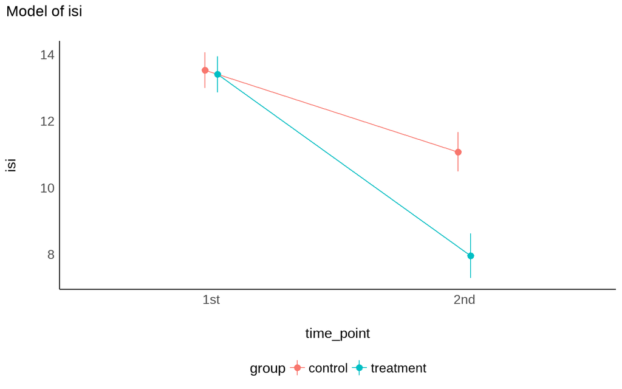

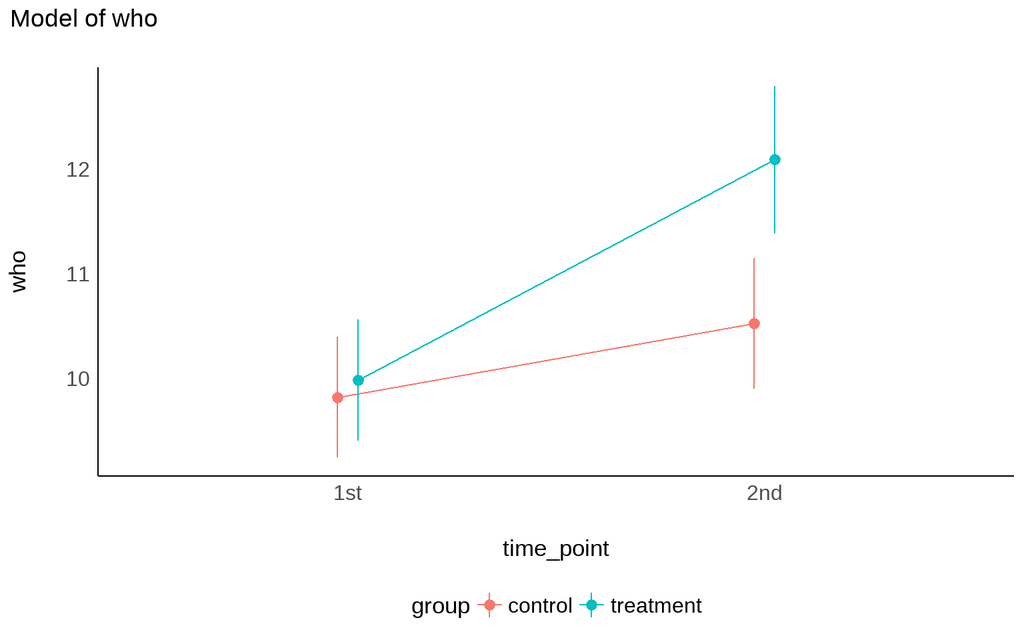

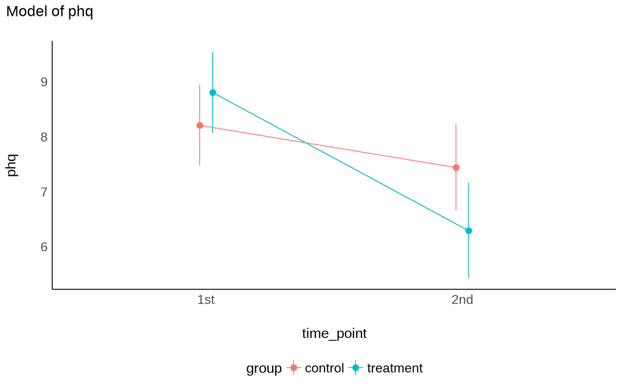

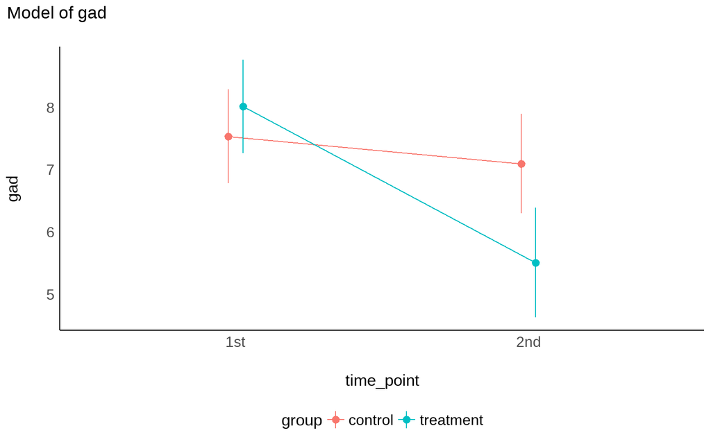

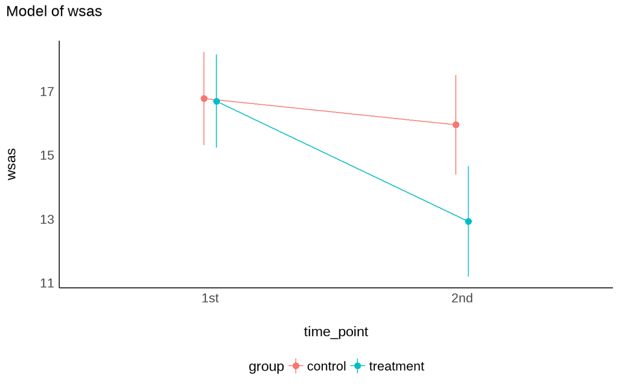

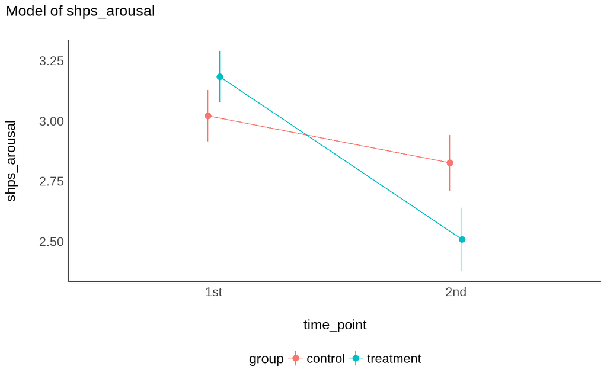

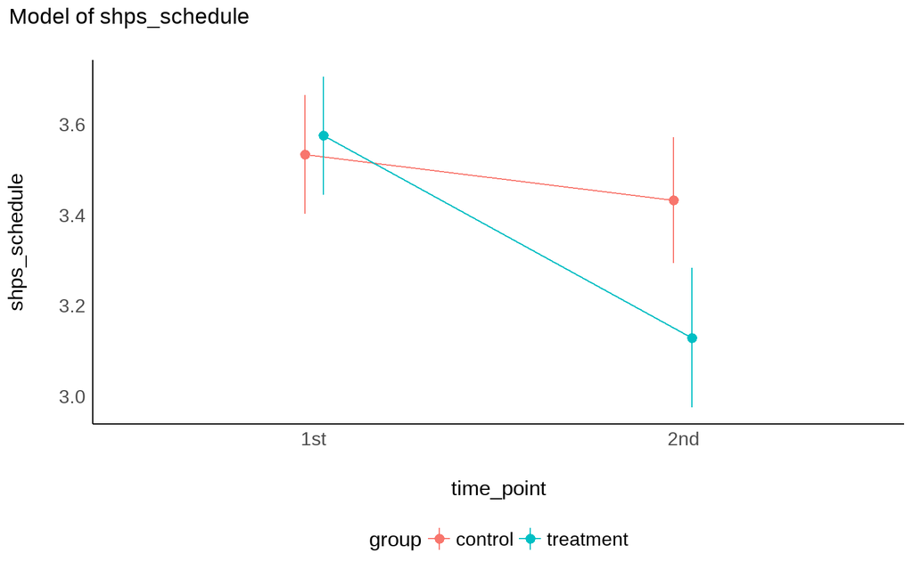

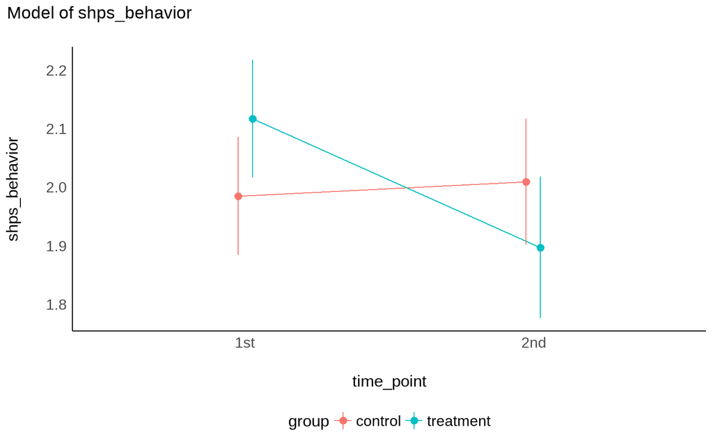

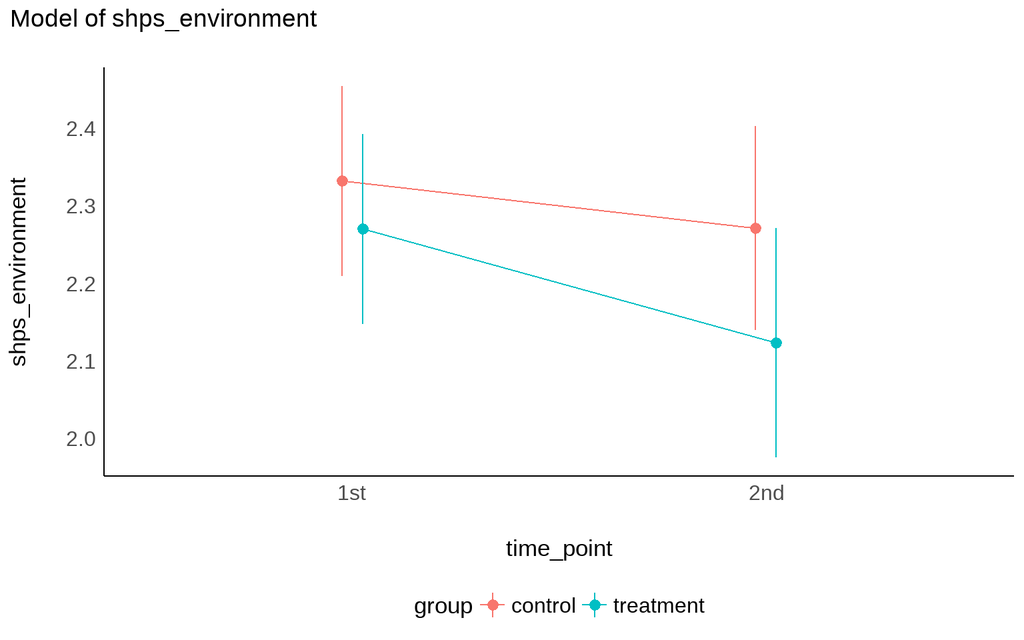

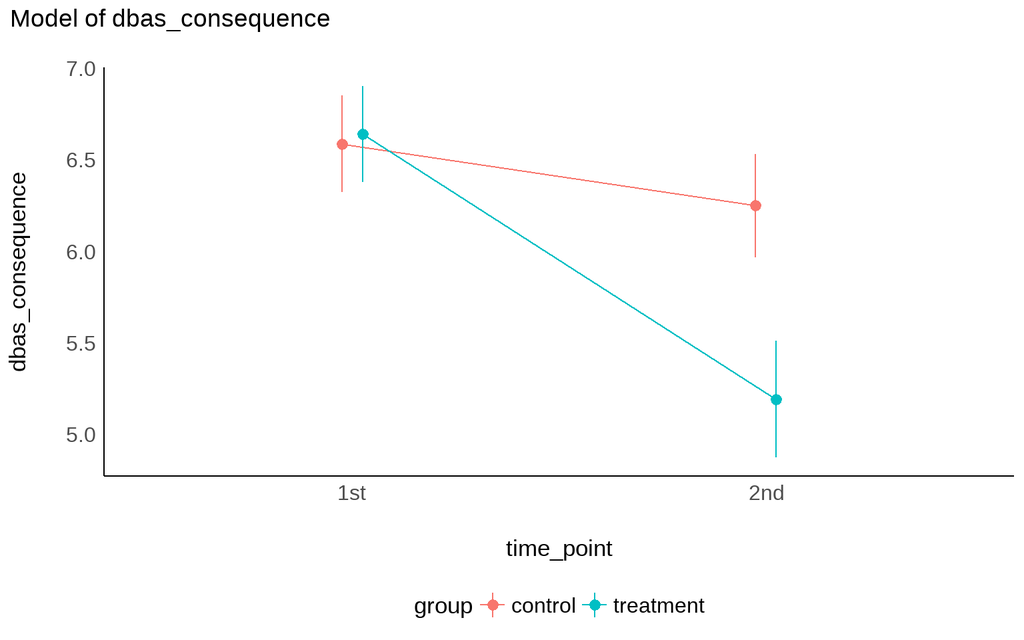

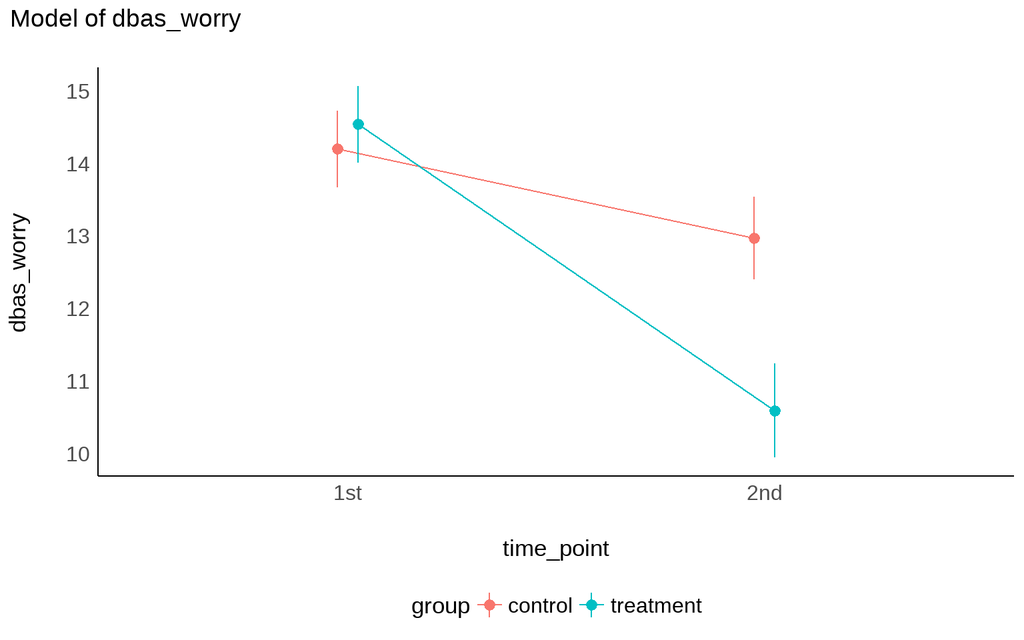

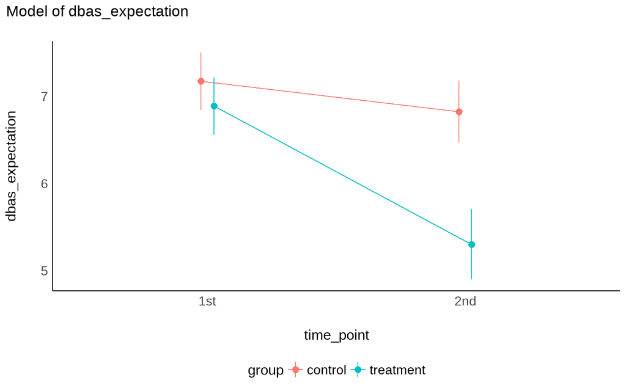

[9 more figures not shown]